# RinActionChap03 Getting started with graphs

Tony

## Getting started with graphs

### Working with graphs

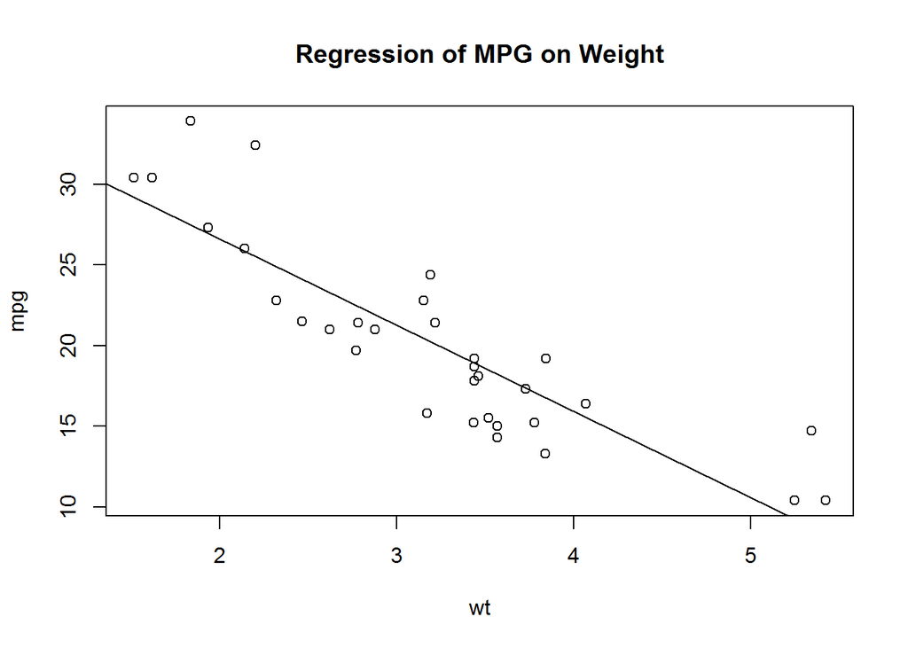

```r
attach(mtcars)
  plot(wt, mpg)
  abline(lm(mpg~wt))
  title ("Regression of MPG on Weight")
```

```r
detach(mtcars)
```

```r
pdf("mygraph.pdf")
  attach(mtcars)
  plot(wt, mpg)
  abline(lm(mpg~wt))
  title ("Regression of MPG on Weight")
  detach(mtcars)
dev.off()
```

### A simple example

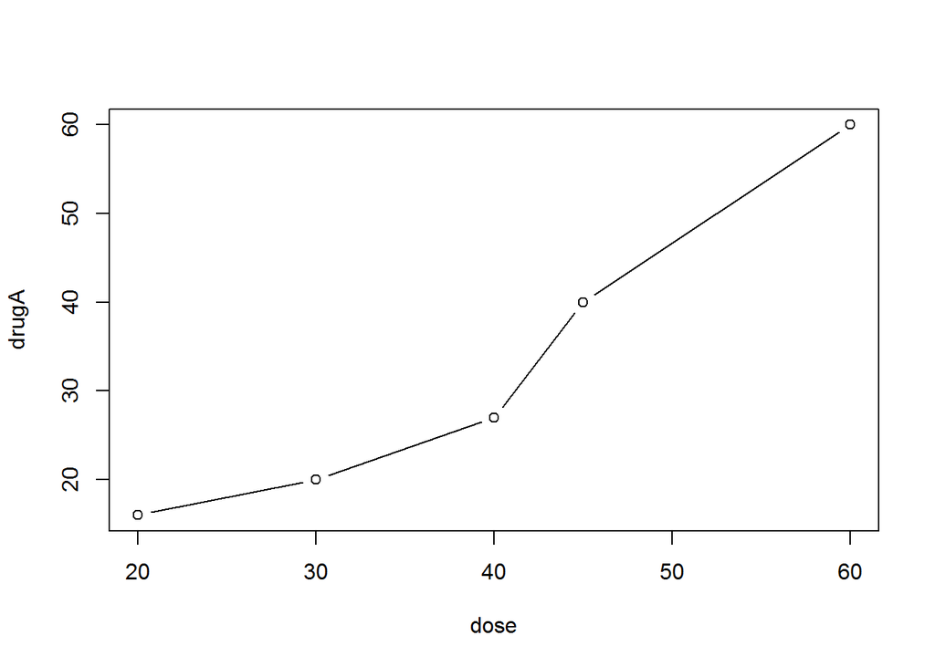

```r
dose <- c(20, 30, 40, 45, 60)
drugA <- c(16, 20, 27, 40, 60)
drugB <- c(15, 18, 25, 31, 40)
plot(dose, drugA, type = "b")
```

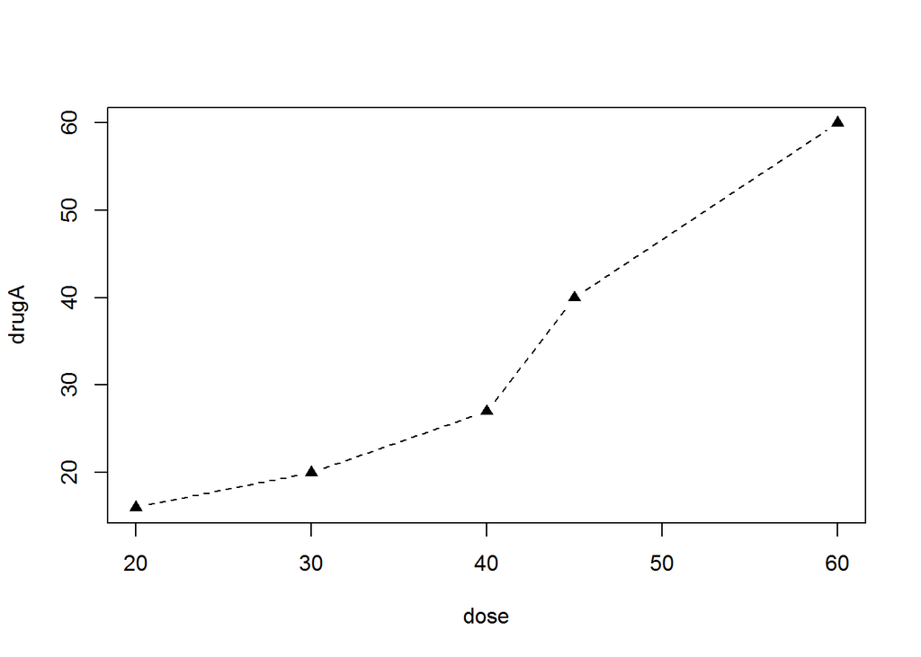

```r
opar <- par(no.readonly = TRUE)
par(lty=2, pch=17)
plot(dose, drugA, type = "b")
```

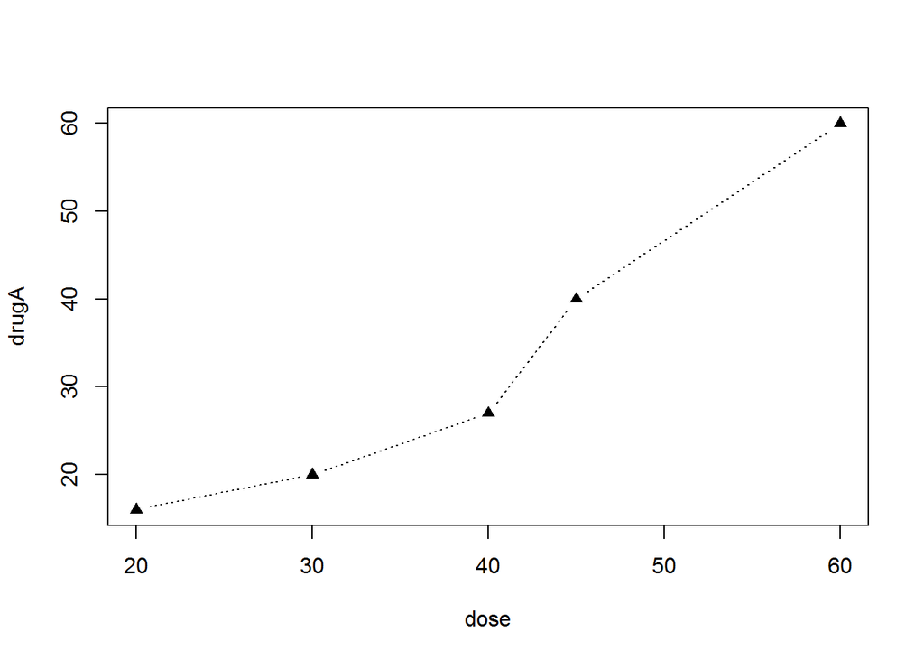

```r
par(opar)

plot(dose, drugA, type = "b", lty=3, pch=17)
```

#### colors

- col plotting color
- col.axis color for axis text
- col.lab labels
- col.main titles
- col.sub subtitles
- fg foreground
- bg background

#### Text characteristics

- cex scaled relative
- cex.axis
- cex.lab
- cex.main
- cex.sub
- font 1=plain, 2=bold, 3=italic, 4=bold italic, 5=symbol
- font.axis
- font.lab
- font.main
- font.sub
- ps font point size
- family standard values are serif, sans and mono

#### Graph and margin dimensions

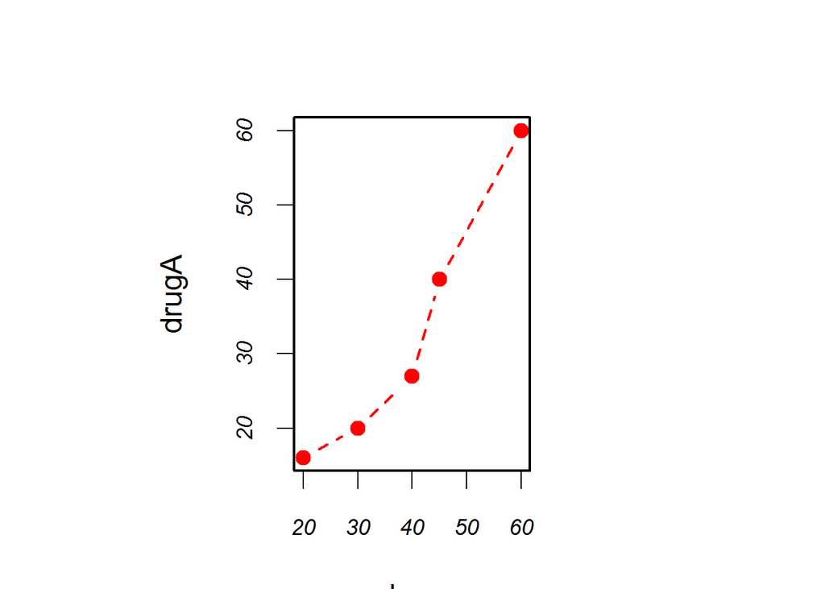

```r
dose  <- c(20, 30, 40, 45, 60)
drugA <- c(16, 20, 27, 40, 60)
drugB <- c(15, 18, 25, 31, 40)
opar <- par(no.readonly=TRUE)
par(pin=c(2, 3))
par(lwd=2, cex=1.5)
par(cex.axis=.75, font.axis=3)
plot(dose, drugA, type="b", pch=19, lty=2, col="red")
```

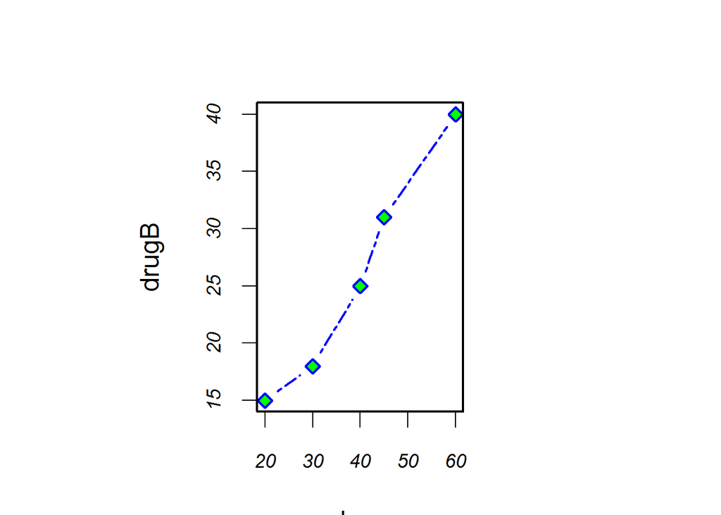

```r
plot(dose, drugB, type="b", pch=23, lty=6, col="blue", bg="green")
```

```r
par(opar)
```

### Adding text, customized axes, and legends

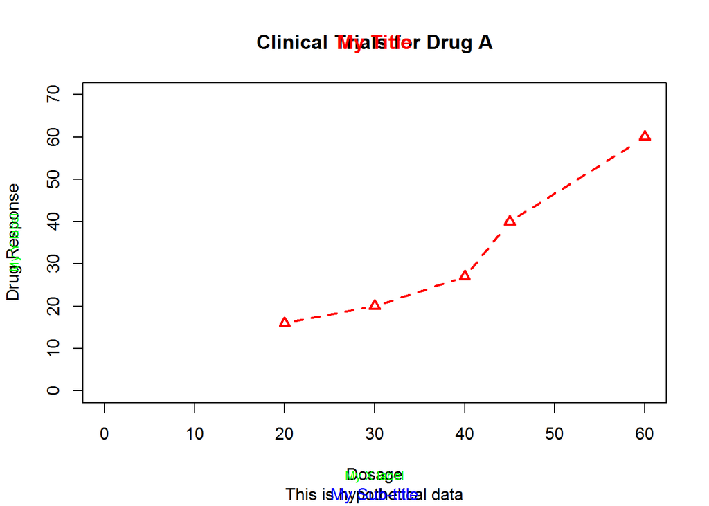

```r
plot(dose, drugA, type="b", col="red", lty=2, pch=2, lwd=2, main="Clinical Trials for Drug A",  sub="This is hypothetical data", xlab="Dosage", ylab="Drug Response", xlim=c(0, 60), ylim=c(0, 70))
title(main="My Title", col.main="red", sub="My Sub-title", col.sub="blue", xlab="My X label", ylab="My Y label", col.lab="green", cex.lab=0.75)
```

#### Axis options

- side an integer indicating the side of the graph to draw the axis(1=bot, 2=left, 3=top, 4=right)
- at vector where tick marks should be drawn
- labels vector of labels to placed at the tick marks
- pos coordinate at which the axis line is to be drawn
- lty line type
- col the lien and tick mark color
- las labels are parallel(=0) or perpendicular(=2) to the axis
- tck length to tick mark of the plotting region

#### reference lines

```
abline(h=yvalues, v=xvalues)
abline(v=seq(1,10,2), lty=2, col="blue")
```

#### Legend

```
legend(location, title, legend)
```

#### Text annotations

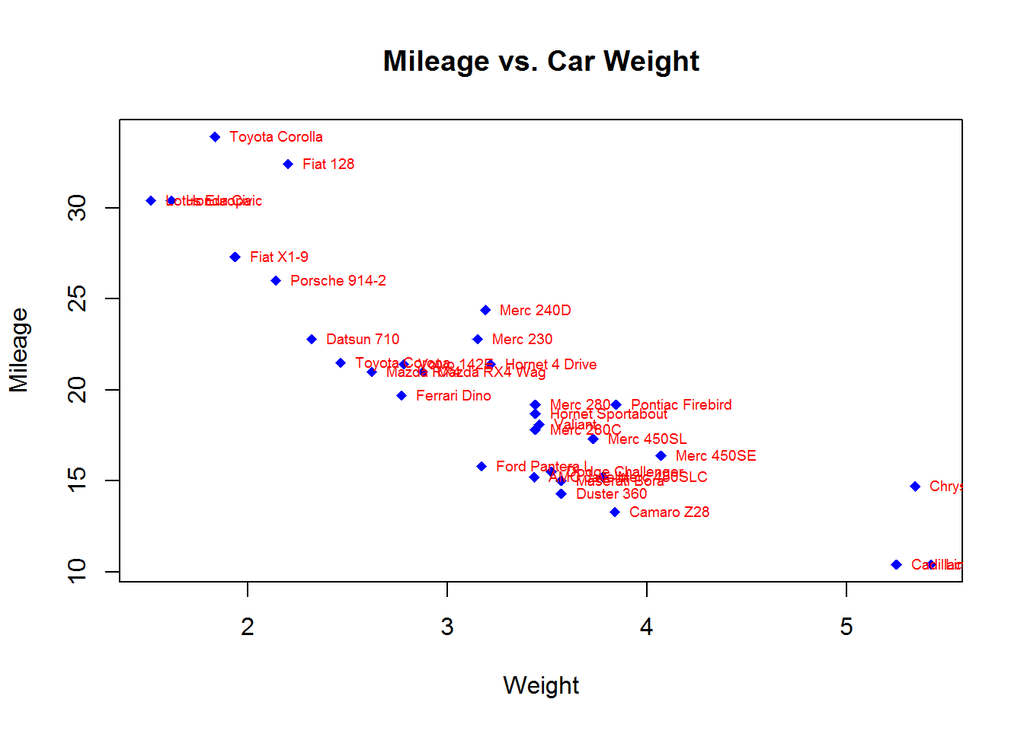

```r
attach(mtcars)
plot(wt, mpg,
main="Mileage vs. Car Weight",
xlab="Weight", ylab="Mileage",
pch=18, col="blue")
text(wt, mpg,
row.names(mtcars),
cex=0.6, pos=4, col="red")
```

```r
detach(mtcars)
```

### Combining graphs

par()

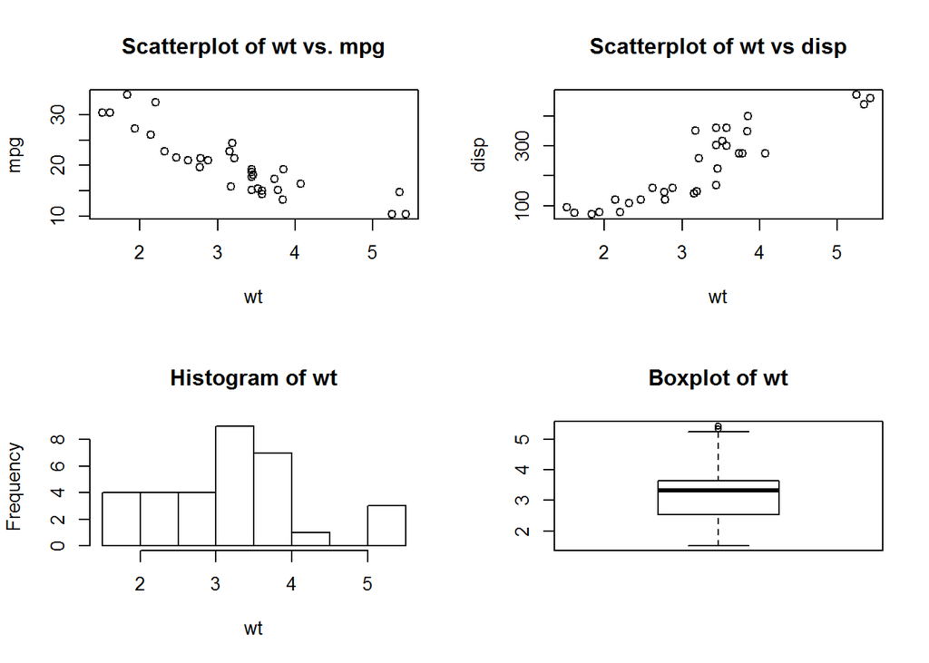

```r
attach(mtcars)
opar <- par(no.readonly=TRUE)
par(mfrow=c(2,2))
plot(wt,mpg, main="Scatterplot of wt vs. mpg")
plot(wt,disp, main="Scatterplot of wt vs disp")
hist(wt, main="Histogram of wt")
boxplot(wt, main="Boxplot of wt")
```

```r
par(opar)
detach(mtcars)
```

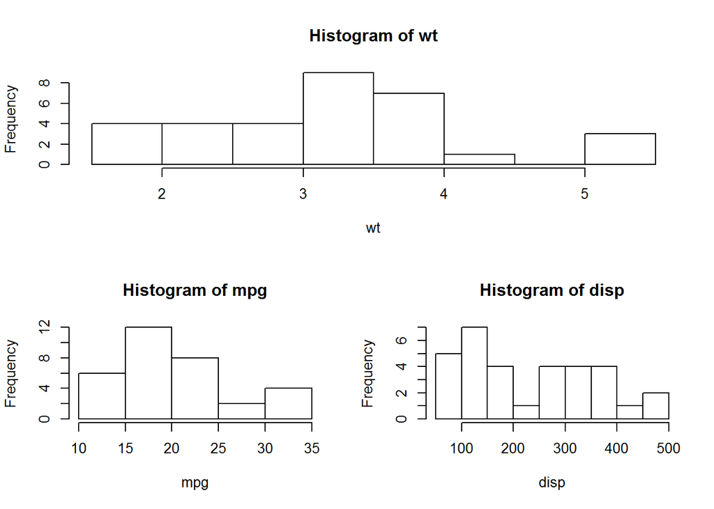

```r
attach(mtcars)
layout(matrix(c(1,1,2,3), 2, 2, byrow = TRUE))
hist(wt)
hist(mpg)
hist(disp)
```

```r
detach(mtcars)
```